# Risk Factor Analysis

## Outcome Variable

**Outcome Variable:** stunted

## Predictor Variables

**Intervention Variable:** tr

**Adjustment Set:**

unadjusted

## Stratifying Variables

The analysis was stratified on these variable(s):

- nhh
- agecat
- studyid
- country

## Data Summary

| nhh | agecat | studyid | country | tr | stunted | n_cell | n |
| --- | --- | --- | --- | --- | --- | --- | --- |
| 3 or less | 24 months | ki1000107-Serrinha-VitA | BRAZIL | Control | 0 | 5 | 19 |
| 3 or less | 24 months | ki1000107-Serrinha-VitA | BRAZIL | Control | 1 | 4 | 19 |
| 3 or less | 24 months | ki1000107-Serrinha-VitA | BRAZIL | VitA | 0 | 7 | 19 |
| 3 or less | 24 months | ki1000107-Serrinha-VitA | BRAZIL | VitA | 1 | 3 | 19 |
| 8+ | 24 months | ki1000107-Serrinha-VitA | BRAZIL | Control | 0 | 3 | 18 |
| 8+ | 24 months | ki1000107-Serrinha-VitA | BRAZIL | Control | 1 | 6 | 18 |
| 8+ | 24 months | ki1000107-Serrinha-VitA | BRAZIL | VitA | 0 | 5 | 18 |
| 8+ | 24 months | ki1000107-Serrinha-VitA | BRAZIL | VitA | 1 | 4 | 18 |
| 4-5 | 24 months | ki1000107-Serrinha-VitA | BRAZIL | Control | 0 | 16 | 45 |
| 4-5 | 24 months | ki1000107-Serrinha-VitA | BRAZIL | Control | 1 | 9 | 45 |
| 4-5 | 24 months | ki1000107-Serrinha-VitA | BRAZIL | VitA | 0 | 13 | 45 |
| 4-5 | 24 months | ki1000107-Serrinha-VitA | BRAZIL | VitA | 1 | 7 | 45 |
| 6-7 | 6 months | ki1000107-Serrinha-VitA | BRAZIL | Control | 0 | 2 | 8 |
| 6-7 | 6 months | ki1000107-Serrinha-VitA | BRAZIL | Control | 1 | 2 | 8 |
| 6-7 | 6 months | ki1000107-Serrinha-VitA | BRAZIL | VitA | 0 | 4 | 8 |
| 6-7 | 6 months | ki1000107-Serrinha-VitA | BRAZIL | VitA | 1 | 0 | 8 |
| 6-7 | 24 months | ki1000107-Serrinha-VitA | BRAZIL | Control | 0 | 12 | 30 |
| 6-7 | 24 months | ki1000107-Serrinha-VitA | BRAZIL | Control | 1 | 6 | 30 |
| 6-7 | 24 months | ki1000107-Serrinha-VitA | BRAZIL | VitA | 0 | 4 | 30 |
| 6-7 | 24 months | ki1000107-Serrinha-VitA | BRAZIL | VitA | 1 | 8 | 30 |
| 4-5 | 6 months | ki1000107-Serrinha-VitA | BRAZIL | Control | 0 | 3 | 8 |
| 4-5 | 6 months | ki1000107-Serrinha-VitA | BRAZIL | Control | 1 | 1 | 8 |
| 4-5 | 6 months | ki1000107-Serrinha-VitA | BRAZIL | VitA | 0 | 3 | 8 |
| 4-5 | 6 months | ki1000107-Serrinha-VitA | BRAZIL | VitA | 1 | 1 | 8 |
| 8+ | 6 months | ki1000107-Serrinha-VitA | BRAZIL | Control | 0 | 0 | 4 |
| 8+ | 6 months | ki1000107-Serrinha-VitA | BRAZIL | Control | 1 | 1 | 4 |
| 8+ | 6 months | ki1000107-Serrinha-VitA | BRAZIL | VitA | 0 | 2 | 4 |
| 8+ | 6 months | ki1000107-Serrinha-VitA | BRAZIL | VitA | 1 | 1 | 4 |
| 3 or less | 6 months | ki1000107-Serrinha-VitA | BRAZIL | Control | 0 | 3 | 9 |
| 3 or less | 6 months | ki1000107-Serrinha-VitA | BRAZIL | VitA | 0 | 6 | 9 |

[output cut: 277 more lines]

The following strata were considered:

- nhh: 3 or less, agecat: 24 months, studyid: iLiNS_DYADM_LNS, country: MALAWI
- nhh: 3 or less, agecat: 24 months, studyid: ki1000107-Serrinha-VitA, country: BRAZIL
- nhh: 3 or less, agecat: 24 months, studyid: ki1000110-WASH-Bangladesh, country: BANGLADESH
- nhh: 3 or less, agecat: 24 months, studyid: ki1000111-WASH-Kenya, country: KENYA
- nhh: 3 or less, agecat: 24 months, studyid: ki1000304-Vitamin-B12, country: INDIA
- nhh: 3 or less, agecat: 24 months, studyid: ki1000304-ZnMort, country: INDIA
- nhh: 3 or less, agecat: 24 months, studyid: ki1148112-iLiNS-DYAD-M, country: MALAWI
- nhh: 3 or less, agecat: 24 months, studyid: ki1148112-LCNI-5, country: MALAWI
- nhh: 3 or less, agecat: 6 months, studyid: iLiNS_DYADM_LNS, country: MALAWI
- nhh: 3 or less, agecat: 6 months, studyid: ki1000107-Serrinha-VitA, country: BRAZIL
- nhh: 3 or less, agecat: 6 months, studyid: ki1000110-WASH-Bangladesh, country: BANGLADESH
- nhh: 3 or less, agecat: 6 months, studyid: ki1000111-WASH-Kenya, country: KENYA
- nhh: 3 or less, agecat: 6 months, studyid: ki1000304-Vitamin-B12, country: INDIA
- nhh: 3 or less, agecat: 6 months, studyid: ki1000304-ZnMort, country: INDIA
- nhh: 3 or less, agecat: 6 months, studyid: ki1000304b-SAS-FoodSuppl, country: INDIA
- nhh: 3 or less, agecat: 6 months, studyid: ki1017093b-PROVIDE, country: BANGLADESH
- nhh: 3 or less, agecat: 6 months, studyid: ki1148112-iLiNS-DYAD-M, country: MALAWI
- nhh: 3 or less, agecat: 6 months, studyid: ki1148112-LCNI-5, country: MALAWI
- nhh: 4-5, agecat: 24 months, studyid: iLiNS_DYADM_LNS, country: MALAWI
- nhh: 4-5, agecat: 24 months, studyid: ki1000107-Serrinha-VitA, country: BRAZIL
- nhh: 4-5, agecat: 24 months, studyid: ki1000110-WASH-Bangladesh, country: BANGLADESH
- nhh: 4-5, agecat: 24 months, studyid: ki1000111-WASH-Kenya, country: KENYA
- nhh: 4-5, agecat: 24 months, studyid: ki1000304-Vitamin-B12, country: INDIA
- nhh: 4-5, agecat: 24 months, studyid: ki1000304-ZnMort, country: INDIA
- nhh: 4-5, agecat: 24 months, studyid: ki1017093b-PROVIDE, country: BANGLADESH
- nhh: 4-5, agecat: 24 months, studyid: ki1148112-iLiNS-DYAD-M, country: MALAWI
- nhh: 4-5, agecat: 24 months, studyid: ki1148112-LCNI-5, country: MALAWI
- nhh: 4-5, agecat: 6 months, studyid: iLiNS_DYADM_LNS, country: MALAWI
- nhh: 4-5, agecat: 6 months, studyid: ki1000107-Serrinha-VitA, country: BRAZIL
- nhh: 4-5, agecat: 6 months, studyid: ki1000110-WASH-Bangladesh, country: BANGLADESH
- nhh: 4-5, agecat: 6 months, studyid: ki1000111-WASH-Kenya, country: KENYA
- nhh: 4-5, agecat: 6 months, studyid: ki1000304-Vitamin-B12, country: INDIA
- nhh: 4-5, agecat: 6 months, studyid: ki1000304-ZnMort, country: INDIA
- nhh: 4-5, agecat: 6 months, studyid: ki1000304b-SAS-FoodSuppl, country: INDIA
- nhh: 4-5, agecat: 6 months, studyid: ki1017093b-PROVIDE, country: BANGLADESH
- nhh: 4-5, agecat: 6 months, studyid: ki1148112-iLiNS-DYAD-M, country: MALAWI
- nhh: 4-5, agecat: 6 months, studyid: ki1148112-LCNI-5, country: MALAWI
- nhh: 6-7, agecat: 24 months, studyid: ki1000107-Serrinha-VitA, country: BRAZIL
- nhh: 6-7, agecat: 24 months, studyid: ki1000110-WASH-Bangladesh, country: BANGLADESH
- nhh: 6-7, agecat: 24 months, studyid: ki1000111-WASH-Kenya, country: KENYA
- nhh: 6-7, agecat: 24 months, studyid: ki1000304-Vitamin-B12, country: INDIA
- nhh: 6-7, agecat: 24 months, studyid: ki1000304-ZnMort, country: INDIA
- nhh: 6-7, agecat: 24 months, studyid: ki1148112-LCNI-5, country: MALAWI
- nhh: 6-7, agecat: 6 months, studyid: iLiNS_DYADM_LNS, country: MALAWI
- nhh: 6-7, agecat: 6 months, studyid: ki1000107-Serrinha-VitA, country: BRAZIL
- nhh: 6-7, agecat: 6 months, studyid: ki1000110-WASH-Bangladesh, country: BANGLADESH
- nhh: 6-7, agecat: 6 months, studyid: ki1000111-WASH-Kenya, country: KENYA
- nhh: 6-7, agecat: 6 months, studyid: ki1000304-Vitamin-B12, country: INDIA
- nhh: 6-7, agecat: 6 months, studyid: ki1000304-ZnMort, country: INDIA
- nhh: 6-7, agecat: 6 months, studyid: ki1000304b-SAS-FoodSuppl, country: INDIA
- nhh: 6-7, agecat: 6 months, studyid: ki1017093b-PROVIDE, country: BANGLADESH
- nhh: 6-7, agecat: 6 months, studyid: ki1148112-iLiNS-DYAD-M, country: MALAWI
- nhh: 6-7, agecat: 6 months, studyid: ki1148112-LCNI-5, country: MALAWI
- nhh: 8+, agecat: 24 months, studyid: iLiNS_DYADM_LNS, country: MALAWI
- nhh: 8+, agecat: 24 months, studyid: ki1000107-Serrinha-VitA, country: BRAZIL
- nhh: 8+, agecat: 24 months, studyid: ki1000110-WASH-Bangladesh, country: BANGLADESH
- nhh: 8+, agecat: 24 months, studyid: ki1000111-WASH-Kenya, country: KENYA
- nhh: 8+, agecat: 24 months, studyid: ki1000304-Vitamin-B12, country: INDIA
- nhh: 8+, agecat: 24 months, studyid: ki1000304-ZnMort, country: INDIA
- nhh: 8+, agecat: 24 months, studyid: ki1148112-iLiNS-DYAD-M, country: MALAWI
- nhh: 8+, agecat: 24 months, studyid: ki1148112-LCNI-5, country: MALAWI
- nhh: 8+, agecat: 6 months, studyid: iLiNS_DYADM_LNS, country: MALAWI
- nhh: 8+, agecat: 6 months, studyid: ki1000107-Serrinha-VitA, country: BRAZIL
- nhh: 8+, agecat: 6 months, studyid: ki1000110-WASH-Bangladesh, country: BANGLADESH
- nhh: 8+, agecat: 6 months, studyid: ki1000111-WASH-Kenya, country: KENYA
- nhh: 8+, agecat: 6 months, studyid: ki1000304-Vitamin-B12, country: INDIA
- nhh: 8+, agecat: 6 months, studyid: ki1000304-ZnMort, country: INDIA
- nhh: 8+, agecat: 6 months, studyid: ki1000304b-SAS-FoodSuppl, country: INDIA
- nhh: 8+, agecat: 6 months, studyid: ki1017093b-PROVIDE, country: BANGLADESH
- nhh: 8+, agecat: 6 months, studyid: ki1148112-iLiNS-DYAD-M, country: MALAWI
- nhh: 8+, agecat: 6 months, studyid: ki1148112-LCNI-5, country: MALAWI

### Dropped Strata

Some strata were dropped due to rare outcomes:

- nhh: 3 or less, agecat: 24 months, studyid: ki1000107-Serrinha-VitA, country: BRAZIL
- nhh: 8+, agecat: 24 months, studyid: ki1000107-Serrinha-VitA, country: BRAZIL
- nhh: 6-7, agecat: 6 months, studyid: ki1000107-Serrinha-VitA, country: BRAZIL
- nhh: 6-7, agecat: 24 months, studyid: ki1000107-Serrinha-VitA, country: BRAZIL
- nhh: 4-5, agecat: 6 months, studyid: ki1000107-Serrinha-VitA, country: BRAZIL
- nhh: 8+, agecat: 6 months, studyid: ki1000107-Serrinha-VitA, country: BRAZIL
- nhh: 3 or less, agecat: 6 months, studyid: ki1000107-Serrinha-VitA, country: BRAZIL
- nhh: 6-7, agecat: 6 months, studyid: ki1000110-WASH-Bangladesh, country: BANGLADESH
- nhh: 8+, agecat: 6 months, studyid: ki1000110-WASH-Bangladesh, country: BANGLADESH
- nhh: 8+, agecat: 6 months, studyid: ki1000111-WASH-Kenya, country: KENYA
- nhh: 4-5, agecat: 6 months, studyid: ki1000111-WASH-Kenya, country: KENYA
- nhh: 6-7, agecat: 6 months, studyid: ki1000111-WASH-Kenya, country: KENYA
- nhh: 3 or less, agecat: 6 months, studyid: ki1000111-WASH-Kenya, country: KENYA
- nhh: 6-7, agecat: 6 months, studyid: ki1000304-Vitamin-B12, country: INDIA
- nhh: 3 or less, agecat: 24 months, studyid: ki1000304-Vitamin-B12, country: INDIA
- nhh: 8+, agecat: 6 months, studyid: ki1000304-Vitamin-B12, country: INDIA
- nhh: 4-5, agecat: 6 months, studyid: ki1000304-Vitamin-B12, country: INDIA
- nhh: 4-5, agecat: 24 months, studyid: ki1000304-Vitamin-B12, country: INDIA
- nhh: 6-7, agecat: 24 months, studyid: ki1000304-Vitamin-B12, country: INDIA
- nhh: 3 or less, agecat: 6 months, studyid: ki1000304-Vitamin-B12, country: INDIA
- nhh: 3 or less, agecat: 6 months, studyid: ki1000304-ZnMort, country: INDIA
- nhh: 6-7, agecat: 24 months, studyid: ki1000304-ZnMort, country: INDIA
- nhh: 8+, agecat: 24 months, studyid: ki1000304-ZnMort, country: INDIA
- nhh: 8+, agecat: 6 months, studyid: ki1000304-ZnMort, country: INDIA
- nhh: 3 or less, agecat: 24 months, studyid: ki1000304-ZnMort, country: INDIA
- nhh: 3 or less, agecat: 6 months, studyid: ki1000304b-SAS-FoodSuppl, country: INDIA
- nhh: 4-5, agecat: 6 months, studyid: ki1017093b-PROVIDE, country: BANGLADESH
- nhh: 3 or less, agecat: 6 months, studyid: ki1017093b-PROVIDE, country: BANGLADESH
- nhh: 6-7, agecat: 6 months, studyid: ki1017093b-PROVIDE, country: BANGLADESH
- nhh: 8+, agecat: 6 months, studyid: ki1017093b-PROVIDE, country: BANGLADESH
- nhh: 4-5, agecat: 24 months, studyid: ki1017093b-PROVIDE, country: BANGLADESH
- nhh: 3 or less, agecat: 6 months, studyid: ki1148112-iLiNS-DYAD-M, country: MALAWI
- nhh: 8+, agecat: 6 months, studyid: ki1148112-iLiNS-DYAD-M, country: MALAWI
- nhh: 3 or less, agecat: 24 months, studyid: ki1148112-iLiNS-DYAD-M, country: MALAWI
- nhh: 8+, agecat: 24 months, studyid: ki1148112-iLiNS-DYAD-M, country: MALAWI
- nhh: 4-5, agecat: 24 months, studyid: ki1148112-iLiNS-DYAD-M, country: MALAWI
- nhh: 8+, agecat: 24 months, studyid: ki1148112-LCNI-5, country: MALAWI
- nhh: 3 or less, agecat: 6 months, studyid: iLiNS_DYADM_LNS, country: MALAWI
- nhh: 6-7, agecat: 6 months, studyid: iLiNS_DYADM_LNS, country: MALAWI
- nhh: 8+, agecat: 6 months, studyid: iLiNS_DYADM_LNS, country: MALAWI
- nhh: 8+, agecat: 24 months, studyid: iLiNS_DYADM_LNS, country: MALAWI
- nhh: 3 or less, agecat: 24 months, studyid: iLiNS_DYADM_LNS, country: MALAWI
- nhh: 4-5, agecat: 24 months, studyid: iLiNS_DYADM_LNS, country: MALAWI

## Methods Detail

We’re interested in the causal parameters $E[Y_a]$ for all values of $a \in \mathcal{A}$. These parameters represent the mean outcome if, possibly contrary to fact, we intervened to set all units to have $A=a$. Under the randomization and positivity assumptions, these are identified by the statistical parameters $\psi_a=E_W[E_{Y|A,W}(Y|A=a,W)]$. In addition, we’re interested in the mean of $Y$, $E[Y]$ under no intervention (the observed mean). We will estimate these parameters by using SuperLearner to fit the relevant likelihood factors – $E_{Y|A,W}(Y|A=a,W)$ and $p(A=a|W)$, and then updating our likelihood fit using a joint TMLE.

For unadjusted analyses ($W=\{\}$), initial likelihoods were estimated using Lrnr_glm to estimate the simple $E(Y|A)$ and Lrnr_mean to estimate $p(A)$. For adjusted analyses, a small library containing Lrnr_glmnet, Lrnr_xgboost, and Lrnr_mean was used.

Having estimated these parameters, we will then use the delta method to estimate relative risks and attributable risks relative to a prespecified baseline level of $A$.

# Results Detail

## Results Plots

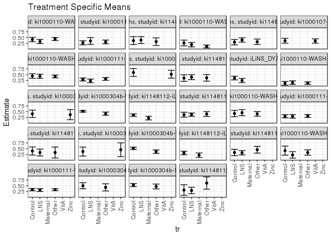

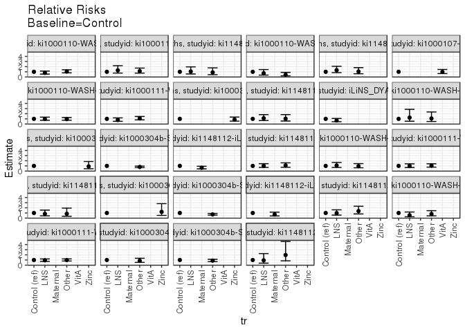

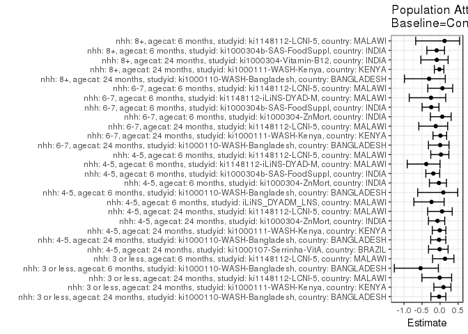

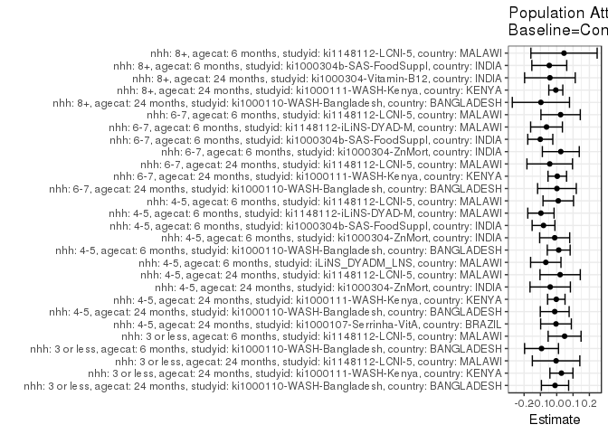

## Results Table

### Parameter: TSM

| nhh | agecat | studyid | country | intervention_level | baseline_level | estimate | ci_lower | ci_upper |
| --- | --- | --- | --- | --- | --- | --- | --- | --- |
| 3 or less | 6 months | ki1000110-WASH-Bangladesh | BANGLADESH | Control | NA | 0.2653061 | 0.1413927 | 0.3892196 |
| 3 or less | 6 months | ki1000110-WASH-Bangladesh | BANGLADESH | LNS | NA | 0.1904762 | 0.0932788 | 0.2876735 |
| 3 or less | 6 months | ki1000110-WASH-Bangladesh | BANGLADESH | Other | NA | 0.1134021 | 0.0501496 | 0.1766545 |
| 3 or less | 6 months | ki1148112-LCNI-5 | MALAWI | Control | NA | 0.3000000 | 0.1837873 | 0.4162127 |
| 3 or less | 6 months | ki1148112-LCNI-5 | MALAWI | LNS | NA | 0.3942308 | 0.3000999 | 0.4883616 |
| 3 or less | 6 months | ki1148112-LCNI-5 | MALAWI | Other | NA | 0.3166667 | 0.1986994 | 0.4346339 |
| 3 or less | 24 months | ki1000110-WASH-Bangladesh | BANGLADESH | Control | NA | 0.4158416 | 0.3196026 | 0.5120805 |
| 3 or less | 24 months | ki1000110-WASH-Bangladesh | BANGLADESH | LNS | NA | 0.3300000 | 0.2377266 | 0.4222734 |
| 3 or less | 24 months | ki1000110-WASH-Bangladesh | BANGLADESH | Other | NA | 0.4368932 | 0.3690773 | 0.5047091 |
| 3 or less | 24 months | ki1000111-WASH-Kenya | KENYA | Control | NA | 0.2727273 | 0.1848303 | 0.3606242 |
| 3 or less | 24 months | ki1000111-WASH-Kenya | KENYA | LNS | NA | 0.3500000 | 0.2019054 | 0.4980946 |
| 3 or less | 24 months | ki1000111-WASH-Kenya | KENYA | Other | NA | 0.3089431 | 0.2271301 | 0.3907560 |
| 3 or less | 24 months | ki1148112-LCNI-5 | MALAWI | Control | NA | 0.3666667 | 0.1933746 | 0.5399588 |
| 3 or less | 24 months | ki1148112-LCNI-5 | MALAWI | LNS | NA | 0.3902439 | 0.2401919 | 0.5402959 |
| 3 or less | 24 months | ki1148112-LCNI-5 | MALAWI | Other | NA | 0.3225806 | 0.1572115 | 0.4879498 |
| 4-5 | 6 months | iLiNS_DYADM_LNS | MALAWI | Control | NA | 0.3500000 | 0.2703631 | 0.4296369 |
| 4-5 | 6 months | iLiNS_DYADM_LNS | MALAWI | LNS | NA | 0.2424242 | 0.1505134 | 0.3343350 |
| 4-5 | 6 months | ki1000110-WASH-Bangladesh | BANGLADESH | Control | NA | 0.1212121 | 0.0423344 | 0.2000899 |
| 4-5 | 6 months | ki1000110-WASH-Bangladesh | BANGLADESH | LNS | NA | 0.1500000 | 0.0716171 | 0.2283829 |
| 4-5 | 6 months | ki1000110-WASH-Bangladesh | BANGLADESH | Other | NA | 0.1294964 | 0.0735827 | 0.1854101 |
| 4-5 | 6 months | ki1000304-ZnMort | INDIA | Control | NA | 0.4054054 | 0.2457752 | 0.5650356 |
| 4-5 | 6 months | ki1000304-ZnMort | INDIA | Zinc | NA | 0.3684211 | 0.1495592 | 0.5872829 |
| 4-5 | 6 months | ki1000304b-SAS-FoodSuppl | INDIA | Control | NA | 0.5151515 | 0.4780095 | 0.5522935 |
| 4-5 | 6 months | ki1000304b-SAS-FoodSuppl | INDIA | Other | NA | 0.4117647 | 0.3423084 | 0.4812210 |
| 4-5 | 6 months | ki1148112-iLiNS-DYAD-M | MALAWI | Control | NA | 0.3500000 | 0.2967410 | 0.4032590 |
| 4-5 | 6 months | ki1148112-iLiNS-DYAD-M | MALAWI | Maternal | NA | 0.2203390 | 0.1408491 | 0.2998289 |
| 4-5 | 6 months | ki1148112-LCNI-5 | MALAWI | Control | NA | 0.3670886 | 0.2606422 | 0.4735350 |
| 4-5 | 6 months | ki1148112-LCNI-5 | MALAWI | LNS | NA | 0.3699422 | 0.2978942 | 0.4419902 |
| 4-5 | 6 months | ki1148112-LCNI-5 | MALAWI | Other | NA | 0.3977273 | 0.2953189 | 0.5001357 |
| 4-5 | 24 months | ki1000107-Serrinha-VitA | BRAZIL | Control | NA | 0.3600000 | 0.2542874 | 0.4657126 |
| 4-5 | 24 months | ki1000107-Serrinha-VitA | BRAZIL | VitA | NA | 0.3500000 | 0.2560447 | 0.4439553 |
| 4-5 | 24 months | ki1000110-WASH-Bangladesh | BANGLADESH | Control | NA | 0.4375000 | 0.3381577 | 0.5368423 |
| 4-5 | 24 months | ki1000110-WASH-Bangladesh | BANGLADESH | LNS | NA | 0.4273504 | 0.3376151 | 0.5170857 |
| 4-5 | 24 months | ki1000110-WASH-Bangladesh | BANGLADESH | Other | NA | 0.4193548 | 0.3578740 | 0.4808357 |
| 4-5 | 24 months | ki1000111-WASH-Kenya | KENYA | Control | NA | 0.2888889 | 0.2226113 | 0.3551664 |
| 4-5 | 24 months | ki1000111-WASH-Kenya | KENYA | LNS | NA | 0.2272727 | 0.1488830 | 0.3056624 |
| 4-5 | 24 months | ki1000111-WASH-Kenya | KENYA | Other | NA | 0.3127753 | 0.2524053 | 0.3731453 |
| 4-5 | 24 months | ki1000304-ZnMort | INDIA | Control | NA | 0.5937500 | 0.4222602 | 0.7652398 |
| 4-5 | 24 months | ki1000304-ZnMort | INDIA | Zinc | NA | 0.5151515 | 0.3433099 | 0.6869931 |
| 4-5 | 24 months | ki1148112-LCNI-5 | MALAWI | Control | NA | 0.3488372 | 0.2059511 | 0.4917233 |
| 4-5 | 24 months | ki1148112-LCNI-5 | MALAWI | LNS | NA | 0.3875000 | 0.2804191 | 0.4945809 |
| 4-5 | 24 months | ki1148112-LCNI-5 | MALAWI | Other | NA | 0.3571429 | 0.2117906 | 0.5024951 |
| 6-7 | 6 months | ki1000304-ZnMort | INDIA | Control | NA | 0.3750000 | 0.1784864 | 0.5715136 |
| 6-7 | 6 months | ki1000304-ZnMort | INDIA | Zinc | NA | 0.4545455 | 0.1559974 | 0.7530935 |
| 6-7 | 6 months | ki1000304b-SAS-FoodSuppl | INDIA | Control | NA | 0.5151515 | 0.4642281 | 0.5660750 |
| 6-7 | 6 months | ki1000304b-SAS-FoodSuppl | INDIA | Other | NA | 0.3717949 | 0.2960872 | 0.4475026 |
| 6-7 | 6 months | ki1148112-iLiNS-DYAD-M | MALAWI | Control | NA | 0.3125000 | 0.2359932 | 0.3890068 |
| 6-7 | 6 months | ki1148112-iLiNS-DYAD-M | MALAWI | Maternal | NA | 0.2187500 | 0.1222511 | 0.3152489 |
| 6-7 | 6 months | ki1148112-LCNI-5 | MALAWI | Control | NA | 0.3333333 | 0.1952212 | 0.4714455 |
| 6-7 | 6 months | ki1148112-LCNI-5 | MALAWI | LNS | NA | 0.3225806 | 0.2273118 | 0.4178495 |
| 6-7 | 6 months | ki1148112-LCNI-5 | MALAWI | Other | NA | 0.4545455 | 0.3070135 | 0.6020774 |
| 6-7 | 24 months | ki1000110-WASH-Bangladesh | BANGLADESH | Control | NA | 0.4200000 | 0.2828465 | 0.5571535 |
| 6-7 | 24 months | ki1000110-WASH-Bangladesh | BANGLADESH | LNS | NA | 0.4545455 | 0.3226166 | 0.5864743 |
| 6-7 | 24 months | ki1000110-WASH-Bangladesh | BANGLADESH | Other | NA | 0.4021739 | 0.3017231 | 0.5026248 |
| 6-7 | 24 months | ki1000111-WASH-Kenya | KENYA | Control | NA | 0.2994012 | 0.2298693 | 0.3689331 |
| 6-7 | 24 months | ki1000111-WASH-Kenya | KENYA | LNS | NA | 0.2936508 | 0.2140493 | 0.3732523 |
| 6-7 | 24 months | ki1000111-WASH-Kenya | KENYA | Other | NA | 0.3110048 | 0.2481845 | 0.3738250 |
| 6-7 | 24 months | ki1148112-LCNI-5 | MALAWI | Control | NA | 0.4000000 | 0.2236426 | 0.5763574 |
| 6-7 | 24 months | ki1148112-LCNI-5 | MALAWI | LNS | NA | 0.3333333 | 0.1844966 | 0.4821701 |
| 6-7 | 24 months | ki1148112-LCNI-5 | MALAWI | Other | NA | 0.3333333 | 0.0933413 | 0.5733254 |
| 8+ | 6 months | ki1000304b-SAS-FoodSuppl | INDIA | Control | NA | 0.5294118 | 0.4638231 | 0.5950005 |
| 8+ | 6 months | ki1000304b-SAS-FoodSuppl | INDIA | Other | NA | 0.4666667 | 0.3600080 | 0.5733254 |
| 8+ | 6 months | ki1148112-LCNI-5 | MALAWI | Control | NA | 0.3125000 | 0.0837432 | 0.5412568 |
| 8+ | 6 months | ki1148112-LCNI-5 | MALAWI | LNS | NA | 0.2926829 | 0.1524059 | 0.4329599 |
| 8+ | 6 months | ki1148112-LCNI-5 | MALAWI | Other | NA | 0.6153846 | 0.3490133 | 0.8817560 |
| 8+ | 24 months | ki1000110-WASH-Bangladesh | BANGLADESH | Control | NA | 0.4166667 | 0.2186132 | 0.6147201 |
| 8+ | 24 months | ki1000110-WASH-Bangladesh | BANGLADESH | LNS | NA | 0.2285714 | 0.0888831 | 0.3682598 |
| 8+ | 24 months | ki1000110-WASH-Bangladesh | BANGLADESH | Other | NA | 0.3333333 | 0.2164483 | 0.4502183 |
| 8+ | 24 months | ki1000111-WASH-Kenya | KENYA | Control | NA | 0.3312102 | 0.2791266 | 0.3832938 |
| 8+ | 24 months | ki1000111-WASH-Kenya | KENYA | LNS | NA | 0.3125000 | 0.2517696 | 0.3732304 |
| 8+ | 24 months | ki1000111-WASH-Kenya | KENYA | Other | NA | 0.3280899 | 0.2844442 | 0.3717356 |
| 8+ | 24 months | ki1000304-Vitamin-B12 | INDIA | Control | NA | 0.5000000 | 0.3680989 | 0.6319011 |
| 8+ | 24 months | ki1000304-Vitamin-B12 | INDIA | Other | NA | 0.4285714 | 0.2741046 | 0.5830382 |

### Parameter: E(Y)

| nhh | agecat | studyid | country | intervention_level | baseline_level | estimate | ci_lower | ci_upper |
| --- | --- | --- | --- | --- | --- | --- | --- | --- |
| 3 or less | 6 months | ki1000110-WASH-Bangladesh | BANGLADESH | NA | NA | 0.1722488 | 0.1209338 | 0.2235638 |
| 3 or less | 6 months | ki1148112-LCNI-5 | MALAWI | NA | NA | 0.3482143 | 0.2856867 | 0.4107418 |
| 3 or less | 24 months | ki1000110-WASH-Bangladesh | BANGLADESH | NA | NA | 0.4054054 | 0.3576480 | 0.4531628 |
| 3 or less | 24 months | ki1000111-WASH-Kenya | KENYA | NA | NA | 0.3015267 | 0.2458510 | 0.3572024 |
| 3 or less | 24 months | ki1148112-LCNI-5 | MALAWI | NA | NA | 0.3627451 | 0.2689792 | 0.4565110 |
| 4-5 | 6 months | iLiNS_DYADM_LNS | MALAWI | NA | NA | 0.2830189 | 0.1605832 | 0.4054545 |
| 4-5 | 6 months | ki1000110-WASH-Bangladesh | BANGLADESH | NA | NA | 0.1333333 | 0.0937981 | 0.1728686 |
| 4-5 | 6 months | ki1000304-ZnMort | INDIA | NA | NA | 0.3928571 | 0.2637859 | 0.5219284 |
| 4-5 | 6 months | ki1000304b-SAS-FoodSuppl | INDIA | NA | NA | 0.4342105 | 0.3551541 | 0.5132670 |
| 4-5 | 6 months | ki1148112-iLiNS-DYAD-M | MALAWI | NA | NA | 0.2531646 | 0.1566674 | 0.3496618 |
| 4-5 | 6 months | ki1148112-LCNI-5 | MALAWI | NA | NA | 0.3764706 | 0.3248952 | 0.4280459 |
| 4-5 | 24 months | ki1000107-Serrinha-VitA | BRAZIL | NA | NA | 0.3555556 | 0.2141169 | 0.4969942 |
| 4-5 | 24 months | ki1000110-WASH-Bangladesh | BANGLADESH | NA | NA | 0.4251627 | 0.3799855 | 0.4703399 |
| 4-5 | 24 months | ki1000111-WASH-Kenya | KENYA | NA | NA | 0.2862669 | 0.2472658 | 0.3252680 |
| 4-5 | 24 months | ki1000304-ZnMort | INDIA | NA | NA | 0.5538462 | 0.4320608 | 0.6756315 |
| 4-5 | 24 months | ki1148112-LCNI-5 | MALAWI | NA | NA | 0.3696970 | 0.2958175 | 0.4435764 |
| 6-7 | 6 months | ki1000304-ZnMort | INDIA | NA | NA | 0.4000000 | 0.2353301 | 0.5646699 |
| 6-7 | 6 months | ki1000304b-SAS-FoodSuppl | INDIA | NA | NA | 0.4144144 | 0.3223558 | 0.5064730 |
| 6-7 | 6 months | ki1148112-iLiNS-DYAD-M | MALAWI | NA | NA | 0.2500000 | 0.1262059 | 0.3737941 |
| 6-7 | 6 months | ki1148112-LCNI-5 | MALAWI | NA | NA | 0.3571429 | 0.2873378 | 0.4269479 |
| 6-7 | 24 months | ki1000110-WASH-Bangladesh | BANGLADESH | NA | NA | 0.4213198 | 0.3521932 | 0.4904464 |
| 6-7 | 24 months | ki1000111-WASH-Kenya | KENYA | NA | NA | 0.3027888 | 0.2625559 | 0.3430217 |
| 6-7 | 24 months | ki1148112-LCNI-5 | MALAWI | NA | NA | 0.3571429 | 0.2540598 | 0.4602259 |
| 8+ | 6 months | ki1000304b-SAS-FoodSuppl | INDIA | NA | NA | 0.4838710 | 0.3584624 | 0.6092795 |
| 8+ | 6 months | ki1148112-LCNI-5 | MALAWI | NA | NA | 0.3571429 | 0.2440847 | 0.4702010 |
| 8+ | 24 months | ki1000110-WASH-Bangladesh | BANGLADESH | NA | NA | 0.3196721 | 0.2365787 | 0.4027656 |
| 8+ | 24 months | ki1000111-WASH-Kenya | KENYA | NA | NA | 0.3255341 | 0.2962271 | 0.3548410 |
| 8+ | 24 months | ki1000304-Vitamin-B12 | INDIA | NA | NA | 0.4583333 | 0.2547037 | 0.6619630 |

### Parameter: RR

| nhh | agecat | studyid | country | intervention_level | baseline_level | estimate | ci_lower | ci_upper |
| --- | --- | --- | --- | --- | --- | --- | --- | --- |
| 3 or less | 6 months | ki1000110-WASH-Bangladesh | BANGLADESH | Control | Control | 1.0000000 | 1.0000000 | 1.0000000 |
| 3 or less | 6 months | ki1000110-WASH-Bangladesh | BANGLADESH | LNS | Control | 0.7179487 | 0.3594718 | 1.4339106 |
| 3 or less | 6 months | ki1000110-WASH-Bangladesh | BANGLADESH | Other | Control | 0.4274385 | 0.2065026 | 0.8847527 |
| 3 or less | 6 months | ki1148112-LCNI-5 | MALAWI | Control | Control | 1.0000000 | 1.0000000 | 1.0000000 |
| 3 or less | 6 months | ki1148112-LCNI-5 | MALAWI | LNS | Control | 1.3141026 | 0.8336871 | 2.0713593 |
| 3 or less | 6 months | ki1148112-LCNI-5 | MALAWI | Other | Control | 1.0555556 | 0.6167025 | 1.8067019 |
| 3 or less | 24 months | ki1000110-WASH-Bangladesh | BANGLADESH | Control | Control | 1.0000000 | 1.0000000 | 1.0000000 |
| 3 or less | 24 months | ki1000110-WASH-Bangladesh | BANGLADESH | LNS | Control | 0.7935714 | 0.5520150 | 1.1408306 |
| 3 or less | 24 months | ki1000110-WASH-Bangladesh | BANGLADESH | Other | Control | 1.0506241 | 0.7951044 | 1.3882593 |
| 3 or less | 24 months | ki1000111-WASH-Kenya | KENYA | Control | Control | 1.0000000 | 1.0000000 | 1.0000000 |
| 3 or less | 24 months | ki1000111-WASH-Kenya | KENYA | LNS | Control | 1.2833333 | 0.7539501 | 2.1844209 |
| 3 or less | 24 months | ki1000111-WASH-Kenya | KENYA | Other | Control | 1.1327913 | 0.7464362 | 1.7191238 |
| 3 or less | 24 months | ki1148112-LCNI-5 | MALAWI | Control | Control | 1.0000000 | 1.0000000 | 1.0000000 |
| 3 or less | 24 months | ki1148112-LCNI-5 | MALAWI | LNS | Control | 1.0643016 | 0.5787108 | 1.9573468 |
| 3 or less | 24 months | ki1148112-LCNI-5 | MALAWI | Other | Control | 0.8797654 | 0.4380780 | 1.7667793 |
| 4-5 | 6 months | iLiNS_DYADM_LNS | MALAWI | Control | Control | 1.0000000 | 1.0000000 | 1.0000000 |
| 4-5 | 6 months | iLiNS_DYADM_LNS | MALAWI | LNS | Control | 0.6926407 | 0.4451197 | 1.0778026 |
| 4-5 | 6 months | ki1000110-WASH-Bangladesh | BANGLADESH | Control | Control | 1.0000000 | 1.0000000 | 1.0000000 |
| 4-5 | 6 months | ki1000110-WASH-Bangladesh | BANGLADESH | LNS | Control | 1.2375000 | 0.5371446 | 2.8510130 |
| 4-5 | 6 months | ki1000110-WASH-Bangladesh | BANGLADESH | Other | Control | 1.0683453 | 0.4892667 | 2.3328009 |
| 4-5 | 6 months | ki1000304-ZnMort | INDIA | Control | Control | 1.0000000 | 1.0000000 | 1.0000000 |
| 4-5 | 6 months | ki1000304-ZnMort | INDIA | Zinc | Control | 0.9087719 | 0.4455874 | 1.8534329 |
| 4-5 | 6 months | ki1000304b-SAS-FoodSuppl | INDIA | Control | Control | 1.0000000 | 1.0000000 | 1.0000000 |
| 4-5 | 6 months | ki1000304b-SAS-FoodSuppl | INDIA | Other | Control | 0.7993080 | 0.6653439 | 0.9602451 |
| 4-5 | 6 months | ki1148112-iLiNS-DYAD-M | MALAWI | Control | Control | 1.0000000 | 1.0000000 | 1.0000000 |
| 4-5 | 6 months | ki1148112-iLiNS-DYAD-M | MALAWI | Maternal | Control | 0.6295400 | 0.4255781 | 0.9312523 |
| 4-5 | 6 months | ki1148112-LCNI-5 | MALAWI | Control | Control | 1.0000000 | 1.0000000 | 1.0000000 |
| 4-5 | 6 months | ki1148112-LCNI-5 | MALAWI | LNS | Control | 1.0077736 | 0.7106590 | 1.4291067 |
| 4-5 | 6 months | ki1148112-LCNI-5 | MALAWI | Other | Control | 1.0834639 | 0.7351875 | 1.5967275 |
| 4-5 | 24 months | ki1000107-Serrinha-VitA | BRAZIL | Control | Control | 1.0000000 | 1.0000000 | 1.0000000 |
| 4-5 | 24 months | ki1000107-Serrinha-VitA | BRAZIL | VitA | Control | 0.9722222 | 0.6530983 | 1.4472800 |
| 4-5 | 24 months | ki1000110-WASH-Bangladesh | BANGLADESH | Control | Control | 1.0000000 | 1.0000000 | 1.0000000 |
| 4-5 | 24 months | ki1000110-WASH-Bangladesh | BANGLADESH | LNS | Control | 0.9768010 | 0.7169504 | 1.3308314 |
| 4-5 | 24 months | ki1000110-WASH-Bangladesh | BANGLADESH | Other | Control | 0.9585253 | 0.7315102 | 1.2559919 |
| 4-5 | 24 months | ki1000111-WASH-Kenya | KENYA | Control | Control | 1.0000000 | 1.0000000 | 1.0000000 |
| 4-5 | 24 months | ki1000111-WASH-Kenya | KENYA | LNS | Control | 0.7867133 | 0.5198897 | 1.1904790 |
| 4-5 | 24 months | ki1000111-WASH-Kenya | KENYA | Other | Control | 1.0826838 | 0.8022204 | 1.4611998 |
| 4-5 | 24 months | ki1000304-ZnMort | INDIA | Control | Control | 1.0000000 | 1.0000000 | 1.0000000 |
| 4-5 | 24 months | ki1000304-ZnMort | INDIA | Zinc | Control | 0.8676236 | 0.5580892 | 1.3488359 |
| 4-5 | 24 months | ki1148112-LCNI-5 | MALAWI | Control | Control | 1.0000000 | 1.0000000 | 1.0000000 |
| 4-5 | 24 months | ki1148112-LCNI-5 | MALAWI | LNS | Control | 1.1108333 | 0.6777375 | 1.8206911 |
| 4-5 | 24 months | ki1148112-LCNI-5 | MALAWI | Other | Control | 1.0238095 | 0.5747092 | 1.8238544 |
| 6-7 | 6 months | ki1000304-ZnMort | INDIA | Control | Control | 1.0000000 | 1.0000000 | 1.0000000 |
| 6-7 | 6 months | ki1000304-ZnMort | INDIA | Zinc | Control | 1.2121212 | 0.5231585 | 2.8083992 |
| 6-7 | 6 months | ki1000304b-SAS-FoodSuppl | INDIA | Control | Control | 1.0000000 | 1.0000000 | 1.0000000 |
| 6-7 | 6 months | ki1000304b-SAS-FoodSuppl | INDIA | Other | Control | 0.7217195 | 0.5755253 | 0.9050496 |
| 6-7 | 6 months | ki1148112-iLiNS-DYAD-M | MALAWI | Control | Control | 1.0000000 | 1.0000000 | 1.0000000 |
| 6-7 | 6 months | ki1148112-iLiNS-DYAD-M | MALAWI | Maternal | Control | 0.7000000 | 0.4226567 | 1.1593333 |
| 6-7 | 6 months | ki1148112-LCNI-5 | MALAWI | Control | Control | 1.0000000 | 1.0000000 | 1.0000000 |
| 6-7 | 6 months | ki1148112-LCNI-5 | MALAWI | LNS | Control | 0.9677419 | 0.5818115 | 1.6096698 |
| 6-7 | 6 months | ki1148112-LCNI-5 | MALAWI | Other | Control | 1.3636364 | 0.8055963 | 2.3082333 |
| 6-7 | 24 months | ki1000110-WASH-Bangladesh | BANGLADESH | Control | Control | 1.0000000 | 1.0000000 | 1.0000000 |
| 6-7 | 24 months | ki1000110-WASH-Bangladesh | BANGLADESH | LNS | Control | 1.0822511 | 0.6991745 | 1.6752148 |
| 6-7 | 24 months | ki1000110-WASH-Bangladesh | BANGLADESH | Other | Control | 0.9575569 | 0.6347685 | 1.4444877 |
| 6-7 | 24 months | ki1000111-WASH-Kenya | KENYA | Control | Control | 1.0000000 | 1.0000000 | 1.0000000 |
| 6-7 | 24 months | ki1000111-WASH-Kenya | KENYA | LNS | Control | 0.9807937 | 0.6863644 | 1.4015239 |
| 6-7 | 24 months | ki1000111-WASH-Kenya | KENYA | Other | Control | 1.0387560 | 0.7635585 | 1.4131387 |
| 6-7 | 24 months | ki1148112-LCNI-5 | MALAWI | Control | Control | 1.0000000 | 1.0000000 | 1.0000000 |
| 6-7 | 24 months | ki1148112-LCNI-5 | MALAWI | LNS | Control | 0.8333333 | 0.4449367 | 1.5607714 |
| 6-7 | 24 months | ki1148112-LCNI-5 | MALAWI | Other | Control | 0.8333333 | 0.3582342 | 1.9385208 |
| 8+ | 6 months | ki1000304b-SAS-FoodSuppl | INDIA | Control | Control | 1.0000000 | 1.0000000 | 1.0000000 |
| 8+ | 6 months | ki1000304b-SAS-FoodSuppl | INDIA | Other | Control | 0.8814815 | 0.6796863 | 1.1431886 |
| 8+ | 6 months | ki1148112-LCNI-5 | MALAWI | Control | Control | 1.0000000 | 1.0000000 | 1.0000000 |
| 8+ | 6 months | ki1148112-LCNI-5 | MALAWI | LNS | Control | 0.9365854 | 0.3904403 | 2.2466740 |
| 8+ | 6 months | ki1148112-LCNI-5 | MALAWI | Other | Control | 1.9692308 | 0.8413234 | 4.6092498 |
| 8+ | 24 months | ki1000110-WASH-Bangladesh | BANGLADESH | Control | Control | 1.0000000 | 1.0000000 | 1.0000000 |
| 8+ | 24 months | ki1000110-WASH-Bangladesh | BANGLADESH | LNS | Control | 0.5485714 | 0.2529248 | 1.1898027 |
| 8+ | 24 months | ki1000110-WASH-Bangladesh | BANGLADESH | Other | Control | 0.8000000 | 0.4431630 | 1.4441640 |
| 8+ | 24 months | ki1000111-WASH-Kenya | KENYA | Control | Control | 1.0000000 | 1.0000000 | 1.0000000 |
| 8+ | 24 months | ki1000111-WASH-Kenya | KENYA | LNS | Control | 0.9435096 | 0.7348129 | 1.2114791 |
| 8+ | 24 months | ki1000111-WASH-Kenya | KENYA | Other | Control | 0.9905791 | 0.8061872 | 1.2171453 |
| 8+ | 24 months | ki1000304-Vitamin-B12 | INDIA | Control | Control | 1.0000000 | 1.0000000 | 1.0000000 |
| 8+ | 24 months | ki1000304-Vitamin-B12 | INDIA | Other | Control | 0.8571429 | 0.5483725 | 1.3397716 |

### Parameter: PAR

| nhh | agecat | studyid | country | intervention_level | baseline_level | estimate | ci_lower | ci_upper |
| --- | --- | --- | --- | --- | --- | --- | --- | --- |
| 3 or less | 6 months | ki1000110-WASH-Bangladesh | BANGLADESH | Control | NA | -0.0930573 | -0.1969228 | 0.0108081 |
| 3 or less | 6 months | ki1148112-LCNI-5 | MALAWI | Control | NA | 0.0482143 | -0.0526820 | 0.1491106 |
| 3 or less | 24 months | ki1000110-WASH-Bangladesh | BANGLADESH | Control | NA | -0.0104362 | -0.0937781 | 0.0729057 |
| 3 or less | 24 months | ki1000111-WASH-Kenya | KENYA | Control | NA | 0.0287994 | -0.0418194 | 0.0994183 |
| 3 or less | 24 months | ki1148112-LCNI-5 | MALAWI | Control | NA | -0.0039216 | -0.1493774 | 0.1415342 |
| 4-5 | 6 months | iLiNS_DYADM_LNS | MALAWI | Control | NA | -0.0669811 | -0.1599782 | 0.0260160 |
| 4-5 | 6 months | ki1000110-WASH-Bangladesh | BANGLADESH | Control | NA | 0.0121212 | -0.0579010 | 0.0821434 |
| 4-5 | 6 months | ki1000304-ZnMort | INDIA | Control | NA | -0.0125483 | -0.1045744 | 0.0794779 |
| 4-5 | 6 months | ki1000304b-SAS-FoodSuppl | INDIA | Control | NA | -0.0809410 | -0.1507292 | -0.0111528 |
| 4-5 | 6 months | ki1148112-iLiNS-DYAD-M | MALAWI | Control | NA | -0.0968354 | -0.1773040 | -0.0163669 |
| 4-5 | 6 months | ki1148112-LCNI-5 | MALAWI | Control | NA | 0.0093820 | -0.0840276 | 0.1027916 |
| 4-5 | 24 months | ki1000107-Serrinha-VitA | BRAZIL | Control | NA | -0.0044444 | -0.0984112 | 0.0895223 |
| 4-5 | 24 months | ki1000110-WASH-Bangladesh | BANGLADESH | Control | NA | -0.0123373 | -0.1006528 | 0.0759781 |
| 4-5 | 24 months | ki1000111-WASH-Kenya | KENYA | Control | NA | -0.0026220 | -0.0560546 | 0.0508106 |
| 4-5 | 24 months | ki1000304-ZnMort | INDIA | Control | NA | -0.0399038 | -0.1635328 | 0.0837251 |
| 4-5 | 24 months | ki1148112-LCNI-5 | MALAWI | Control | NA | 0.0208598 | -0.1025636 | 0.1442831 |
| 6-7 | 6 months | ki1000304-ZnMort | INDIA | Control | NA | 0.0250000 | -0.0880155 | 0.1380155 |
| 6-7 | 6 months | ki1000304b-SAS-FoodSuppl | INDIA | Control | NA | -0.1007371 | -0.1774286 | -0.0240456 |
| 6-7 | 6 months | ki1148112-iLiNS-DYAD-M | MALAWI | Control | NA | -0.0625000 | -0.1598226 | 0.0348226 |
| 6-7 | 6 months | ki1148112-LCNI-5 | MALAWI | Control | NA | 0.0238095 | -0.0966689 | 0.1442879 |
| 6-7 | 24 months | ki1000110-WASH-Bangladesh | BANGLADESH | Control | NA | 0.0013198 | -0.1171741 | 0.1198137 |
| 6-7 | 24 months | ki1000111-WASH-Kenya | KENYA | Control | NA | 0.0033876 | -0.0535041 | 0.0602794 |
| 6-7 | 24 months | ki1148112-LCNI-5 | MALAWI | Control | NA | -0.0428571 | -0.1825439 | 0.0968296 |
| 8+ | 6 months | ki1000304b-SAS-FoodSuppl | INDIA | Control | NA | -0.0455408 | -0.1524306 | 0.0613490 |
| 8+ | 6 months | ki1148112-LCNI-5 | MALAWI | Control | NA | 0.0446429 | -0.1583095 | 0.2475952 |
| 8+ | 24 months | ki1000110-WASH-Bangladesh | BANGLADESH | Control | NA | -0.0969945 | -0.2721997 | 0.0782106 |
| 8+ | 24 months | ki1000111-WASH-Kenya | KENYA | Control | NA | -0.0056761 | -0.0485545 | 0.0372023 |
| 8+ | 24 months | ki1000304-Vitamin-B12 | INDIA | Control | NA | -0.0416667 | -0.1968024 | 0.1134691 |

### Parameter: PAF

| nhh | agecat | studyid | country | intervention_level | baseline_level | estimate | ci_lower | ci_upper |
| --- | --- | --- | --- | --- | --- | --- | --- | --- |
| 3 or less | 6 months | ki1000110-WASH-Bangladesh | BANGLADESH | Control | NA | -0.5402494 | -1.2668673 | -0.0465404 |
| 3 or less | 6 months | ki1148112-LCNI-5 | MALAWI | Control | NA | 0.1384615 | -0.2058527 | 0.3844617 |
| 3 or less | 24 months | ki1000110-WASH-Bangladesh | BANGLADESH | Control | NA | -0.0257426 | -0.2533787 | 0.1605507 |
| 3 or less | 24 months | ki1000111-WASH-Kenya | KENYA | Control | NA | 0.0955121 | -0.1716213 | 0.3017382 |
| 3 or less | 24 months | ki1148112-LCNI-5 | MALAWI | Control | NA | -0.0108108 | -0.5029832 | 0.3201930 |
| 4-5 | 6 months | iLiNS_DYADM_LNS | MALAWI | Control | NA | -0.2366667 | -0.7252857 | 0.1135703 |
| 4-5 | 6 months | ki1000110-WASH-Bangladesh | BANGLADESH | Control | NA | 0.0909091 | -0.6190253 | 0.4895409 |
| 4-5 | 6 months | ki1000304-ZnMort | INDIA | Control | NA | -0.0319410 | -0.2950064 | 0.1776857 |
| 4-5 | 6 months | ki1000304b-SAS-FoodSuppl | INDIA | Control | NA | -0.1864096 | -0.3940551 | -0.0096930 |
| 4-5 | 6 months | ki1148112-iLiNS-DYAD-M | MALAWI | Control | NA | -0.3825000 | -0.9098591 | -0.0007577 |
| 4-5 | 6 months | ki1148112-LCNI-5 | MALAWI | Control | NA | 0.0249209 | -0.2576290 | 0.2439906 |
| 4-5 | 24 months | ki1000107-Serrinha-VitA | BRAZIL | Control | NA | -0.0125000 | -0.3188096 | 0.2226655 |
| 4-5 | 24 months | ki1000110-WASH-Bangladesh | BANGLADESH | Control | NA | -0.0290179 | -0.2592047 | 0.1590900 |
| 4-5 | 24 months | ki1000111-WASH-Kenya | KENYA | Control | NA | -0.0091592 | -0.2141882 | 0.1612484 |
| 4-5 | 24 months | ki1000304-ZnMort | INDIA | Control | NA | -0.0720486 | -0.3213555 | 0.1302203 |
| 4-5 | 24 months | ki1148112-LCNI-5 | MALAWI | Control | NA | 0.0564239 | -0.3441433 | 0.3376184 |
| 6-7 | 6 months | ki1000304-ZnMort | INDIA | Control | NA | 0.0625000 | -0.2676291 | 0.3066535 |
| 6-7 | 6 months | ki1000304b-SAS-FoodSuppl | INDIA | Control | NA | -0.2430830 | -0.4981156 | -0.0314660 |
| 6-7 | 6 months | ki1148112-iLiNS-DYAD-M | MALAWI | Control | NA | -0.2500000 | -0.8537598 | 0.1571184 |
| 6-7 | 6 months | ki1148112-LCNI-5 | MALAWI | Control | NA | 0.0666667 | -0.3397088 | 0.3497758 |
| 6-7 | 24 months | ki1000110-WASH-Bangladesh | BANGLADESH | Control | NA | 0.0031325 | -0.3217955 | 0.2481857 |
| 6-7 | 24 months | ki1000111-WASH-Kenya | KENYA | Control | NA | 0.0111882 | -0.1957413 | 0.1823074 |
| 6-7 | 24 months | ki1148112-LCNI-5 | MALAWI | Control | NA | -0.1200000 | -0.5886428 | 0.2103952 |
| 8+ | 6 months | ki1000304b-SAS-FoodSuppl | INDIA | Control | NA | -0.0941176 | -0.3650093 | 0.1230145 |
| 8+ | 6 months | ki1148112-LCNI-5 | MALAWI | Control | NA | 0.1250000 | -0.6750993 | 0.5429376 |
| 8+ | 24 months | ki1000110-WASH-Bangladesh | BANGLADESH | Control | NA | -0.3034188 | -0.9866723 | 0.1448511 |
| 8+ | 24 months | ki1000111-WASH-Kenya | KENYA | Control | NA | -0.0174363 | -0.1580595 | 0.1061110 |
| 8+ | 24 months | ki1000304-Vitamin-B12 | INDIA | Control | NA | -0.0909091 | -0.5316383 | 0.2230002 |